# Lab 1 Hip Hop

Rachel Loh

1-15-20

```r
library(tidyverse)
```

## R Markdown

1. The dataset is presenting how often certain words are used in various genres of music for artists of different ethnicities. As well, it shows how popular the words are and other charateristics that can be analyzed as to which words to use in which songs.

```r
hiphop <- read_csv("https://www.dropbox.com/s/5d8fwxrj3jtua1z/hiphop.csv?dl=1")
```

2. Cleaning the data

```r
clean_hiphop <- hiphop %>%
  mutate(sex = as.factor(sex), ethnic = as.factor(ethnic))
```

3. How many AAVE words were studied in this dataset?

There are 64 AAVE words

```r
  unique(hiphop$word)
```

```
##  [1] "[to be] ghost"     "5-0"               "A-town"
##  [4] "ashy"              "ay yo trip"        "ballin'"
##  [7] "beezy"             "bones"             "boo"
## [10] "boughie"           "break someone out" "catch the vapors"
## [13] "chedda"            "cheese"            "chitlins"
## [16] "cop my steezy"     "CP time"           "crossroads"
## [19] "crump"             "cuddie"            "dap"
## [22] "dead presidents"   "dollar cab"        "domino"
## [25] "duckets"           "dukey rope"        "dun"
## [28] "face gator"        "facheezie"         "feel me"
## [31] "fetti"             "finna"             "ghostride"
## [34] "good hair"         "gouda"             "grip"
## [37] "grip grain"        "guap"              "hard"
## [40] "heezy"             "hella"             "humming"
## [43] "mail"              "make it rain"      "off the hook"
## [46] "player hater"      "plex"              "road dog"
## [49] "roll deep"         "rollie"            "saditty"
## [52] "skrilla"           "straight cash"     "stupid"
## [55] "sweatbox"          "talking jazz"      "The Nation"
## [58] "toe up"            "trife"             "trill"
## [61] "twurk"             "what it do"        "What it is?"
## [64] "wile out"
```

4. Make a new variable that recategorizes ethnic into only two groups, “white” and “non-white”, to simplify your data.

```r
clean_hiphop <- hiphop %>%
  mutate(ethnic = case_when(ethnic == "white" ~ "white",
                   TRUE ~ "non-white"))
clean_hiphop
```

```
## # A tibble: 10,752 x 38
##    word  subj  sex     age ethnic   city county  intl vocal classical  folk
##    <chr> <chr> <chr> <dbl> <chr>   <dbl>  <dbl> <dbl> <dbl>     <dbl> <dbl>
##  1 [to … p15   Fema…    20 white   33283 1.16e6     0     0         0     0
##  2 [to … p53   Fema…    17 white   34033 3.96e5     0     0         0     0
##  3 [to … p136  Male     41 white    8789 5.87e4     0     2         0     0
##  4 [to … p36   Fema…    18 white     712 1.49e5     0     0         0     1
##  5 [to … p118  Fema…    18 white   24280 1.54e5     0     3         3     0
##  6 [to … p106  Male     19 white  281262 5.06e5     0     0         0     0
##  7 [to … p70   Fema…    18 white  385542 1.16e6     0     0         0     2
##  8 [to … p107  Male     18 white     326 5.06e5     0     0         0     0
##  9 [to … p102  Male     19 non-w…   8471 1.01e5     0     0         0     0
## 10 [to … p83   Male     19 white   72878 1.16e6     0     1         0     0
## # … with 10,742 more rows, and 27 more variables: rock <dbl>, country <dbl>,
## #   pop <dbl>, alternative <dbl>, hiphop <dbl>, unclassifiable <dbl>,
## #   countyBlack <dbl>, jayz <dbl>, barkley <dbl>, boondocks <dbl>,
## #   monique <dbl>, bieber <dbl>, asianMove <dbl>, blackMove <dbl>,
## #   hispanicMove <dbl>, nativeMove <dbl>, SAAMEMove <dbl>, whiteMove <dbl>,
## #   blackWeekly <dbl>, jayz1 <dbl>, boondocks1 <dbl>, familiarity <dbl>,
## #   trial <dbl>, fam1 <dbl>, popularityScore <dbl>, numPreferredArtists <dbl>,
## #   numOverallArtists <dbl>
```

5. What are the demographics of the people in this study? Investigate the variables sex, age, and ethnic and summarize your findings in 1-3 complete sentences.

```r
cleaner_hiphop <- clean_hiphop %>%
  distinct(subj, .keep_all = TRUE)
  count(cleaner_hiphop, vars = ethnic)
```

```
## # A tibble: 2 x 2
##   vars          n
##   <chr>     <int>
## 1 non-white    33
## 2 white       135
```

```r
  summary(cleaner_hiphop$sex)
```

```
##    Length     Class      Mode
##       168 character character
```

```r
  summary(cleaner_hiphop$age)
```

```
##    Min. 1st Qu.  Median    Mean 3rd Qu.    Max.
##   16.00   18.00   19.00   20.02   20.00   48.00
```

6. Make at least two plots to display the demographic information of the subjects in this study.

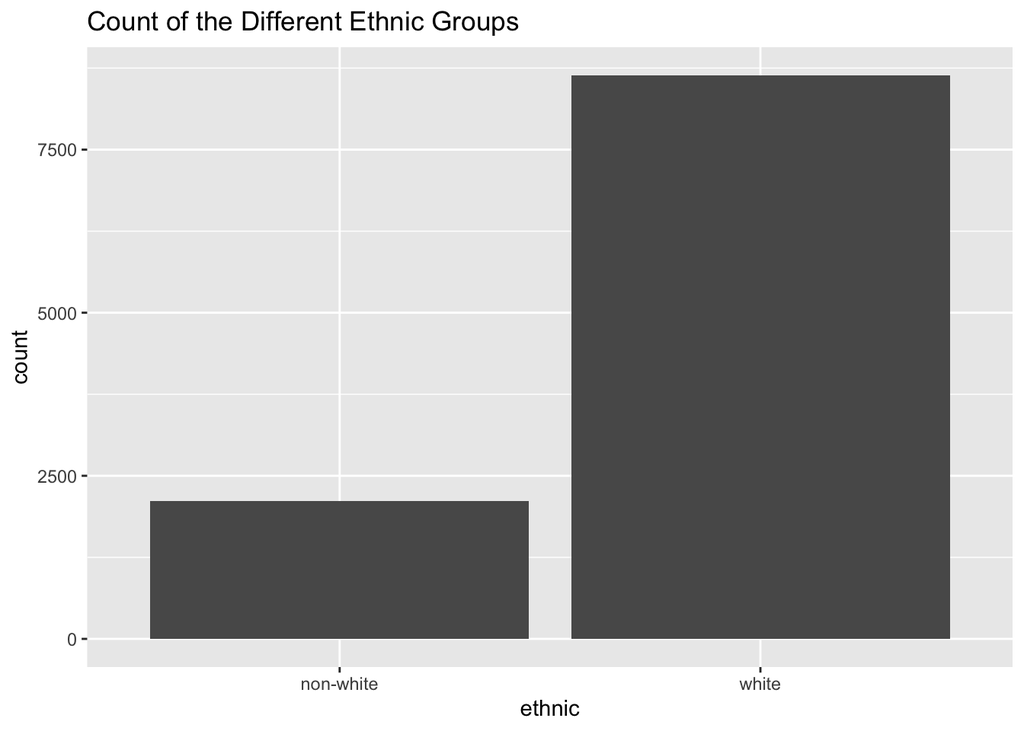

```r
clean_hiphop %>%
  mutate(ethnic = case_when(ethnic == "white" ~ "white",
                   TRUE ~ "non-white")) %>%
  ggplot()+geom_bar(mapping = aes(x = ethnic)) +
  labs(title = "Count of the Different Ethnic Groups")
```

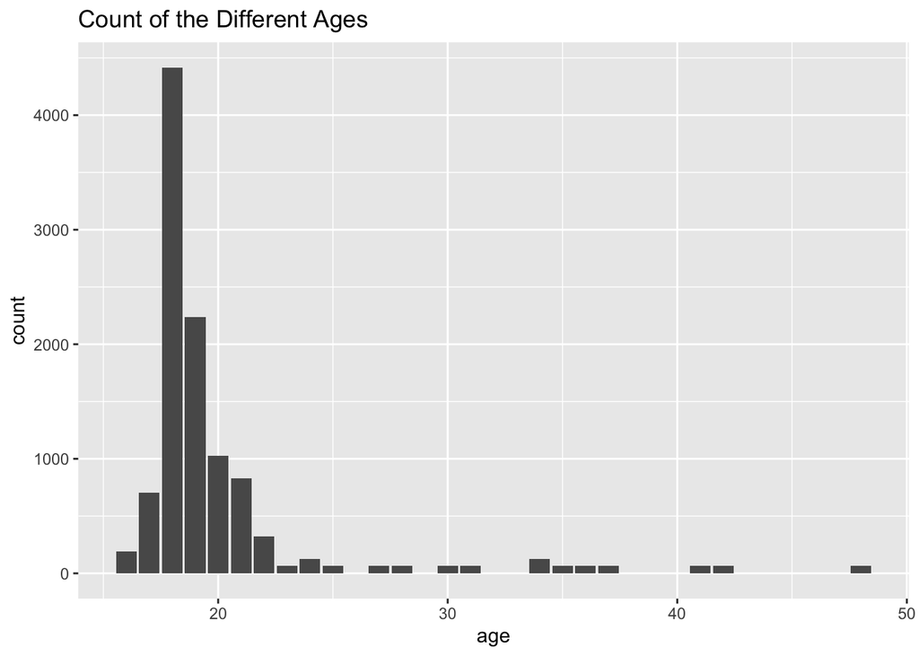

```r
clean_hiphop %>%
  ggplot()+geom_bar(mapping = aes(x = age)) +
  labs(title = "Count of the Different Ages")
```

1. For each demographic group listed below, determine which word(s) in this study was the most and least familiar on average.